# DSC478_assignment1_xy

```python
import numpy as np
import pandas as pd
import matplotlib.pyplot as plt
import seaborn as sns
%pwd
```

```
'/Users/xuyangji/Documents'
```

```python
adult = pd.read_csv('/Users/xuyangji/downloads/adult-modified.csv')
adult.head()
```

|  | age | workclass | education | marital-status | race | sex | hours-per-week | income |
| --- | --- | --- | --- | --- | --- | --- | --- | --- |
| 0 | 39 | Public | 13 | Single | White | Male | 40 | <=50K |
| 1 | 50 | Self-emp | 13 | Married | White | Male | 13 | <=50K |
| 2 | 38 | Private | 9 | Single | White | Male | 40 | <=50K |
| 3 | 53 | Private | 7 | Married | Black | Male | 40 | <=50K |
| 4 | 28 | Private | 13 | Married | Black | Female | 40 | <=50K |

### PS1-3. Data Exploration

The adult.csv file contains 9,412 observations with 8 attributes, each representing a demographic characteristic of adults in the United State.

- Interval-scaled Numeric Attribute: age, education, hours/week
- Ordinal Attribute: income
- Nominal Attribute: workclass, marital status, race, sex

Upon checking the five-point descriptive summary data for numeric variables, the measure of central tendency and data dispersion for those are studied. Boxplot and histogram were used to verify the initial assumption based on descriptive data.

```python
print("The datatype of each variable: \n",adult.dtypes)
print("\n")
print("Checking if missing value exists: \n",adult.isnull().all())
```

```
The datatype of each variable:
 age                int64
workclass         object
education          int64
marital-status    object
race              object
sex               object
hours-per-week     int64
income            object
dtype: object


Checking if missing value exists:
 age               False
workclass         False
education         False
marital-status    False
race              False
sex               False
hours-per-week    False
income            False
dtype: bool
```

### Descriptive Analysis for Numerical Variables

*Solutions for PS1 Part 1 and PS2*

#### I. Five-Point Statistics Analysis

The age variable is expected to be slightly postively skewed, where the mean occurs at a value of 38.4 years old which is greater than the median age of 37 and the mode value of 38 years old. The quartiles give a clear indication of the age distribution, with 50% of the observations lies within the interquartile range of 28 to 47 years old. Based on the IQR, there are many outlying observations lying above the upper whisker fence of 75.5 years old. The standard deviation of approximately 13 indicates the age data are more spread out, while 68% of the age value are at the range of 25 to 51 years old.

```python
#Return statistics about the numerical variables
adult.describe()
```

|  | age | education | hours-per-week |
| --- | --- | --- | --- |
| count | 9412.000000 | 9412.000000 | 9412.000000 |
| mean | 38.357310 | 10.125266 | 41.080217 |
| std | 12.962135 | 2.542118 | 11.884590 |
| min | 17.000000 | 1.000000 | 1.000000 |
| 25% | 28.000000 | 9.000000 | 40.000000 |
| 50% | 37.000000 | 10.000000 | 40.000000 |
| 75% | 47.000000 | 13.000000 | 45.000000 |
| max | 90.000000 | 16.000000 | 99.000000 |

```python
#Return the statistical mode
adult.mode()
```

|  | age | workclass | education | marital-status | race | sex | hours-per-week | income |
| --- | --- | --- | --- | --- | --- | --- | --- | --- |
| 0 | 38 | Private | 9 | Married | White | Male | 40 | <=50K |

#### II. Measure of Central Tendency

Histogram is chosen to summarize the discrete data that are measured on an interval scale, allowing to see the frequency distribution and variability for a large dataset in a clear picture.

For the age variable, the postively skewed unimodal histogram indicates that many of the age value are near the lower end of the quantiles. The elder adults are less frequent in the dataset, often shown as outliers at the high values.

Lastly, the histogram for the hours/week variable shows a roughly symmetric distribution with one peak point at 40. The graph indicates that there are more outlying observations with people working much more hours than the average working hours of 40 per week, comparing to those who work much less hours than the average working hours.

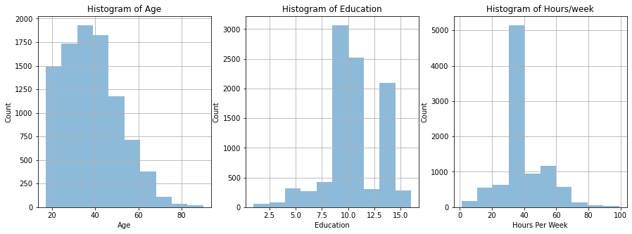

```python
#Age Histogram

plt.figure(figsize=[15,5]) # larger figsize for subplots

plt.subplot(1,3,1)
plt.hist(adult["age"],alpha=.5)
plt.xlabel("Age")
plt.ylabel("Count")
plt.title("Histogram of Age")
plt.grid(True)

plt.subplot(1,3,2)
plt.hist(adult["education"],alpha=.5)
plt.xlabel("Education")
plt.ylabel("Count")
plt.title("Histogram of Education")
plt.grid(True)

plt.subplot(1,3,3)
plt.hist(adult["hours-per-week"],alpha=.5)
plt.xlabel("Hours Per Week")
plt.ylabel("Count")
plt.title("Histogram of Hours/week")
plt.grid(True)
```

#### III. Measure of Data Dispersion

Boxplot is chosen to visualize the data dispersion, as it incorporates the five-point data with three quartiles, two whiskers, and individually plotted outliers.

Looking at the boxplot for age variable, the higher whisker is extended to approxiamtely 75, with observations with values that are greater than 1.5*IQR beyond the higher quartile. Notice that there are many outlying observations plotted around the range of 75-90, indicating there is a greater variability among the elder adults in the dataset.

The boxplot for the education variable is more intersting to study. As the median is closer to the bottom of the interquantile box, the distribution of education variable is skewed. Meantime, as the whisker is longer on the lower end of the box, observations for the education are varied amongst the least positive quartile group, while more similar for the most positive quartile. In addition, the variable has two smaller outliers, which is much less than the other two numerical variables.

Lastly, the boxplot for hours/week variable indicates that there is a less variability in terms of distribution, as the middle 50% of the values tend to be clustered arounf the median. However, a significant number of outliers are present on both side of the box. Since, the median is in the exact Q1 quartile, the data distribution is skewed.

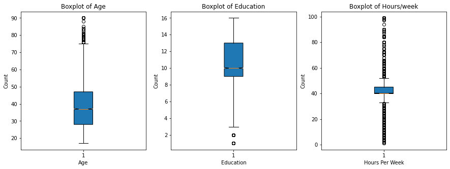

```python
#Boxplot For Numeric Variables

fig= plt.figure(figsize=(15,5))
plt.subplot(1,3,1)
plt.boxplot(adult["age"],patch_artist= True, notch="True")
plt.xlabel("Age")
plt.ylabel("Count")
plt.title("Boxplot of Age")

plt.subplot(1,3,2)
plt.boxplot(adult["education"],patch_artist= True, notch="True")
plt.xlabel("Education")
plt.ylabel("Count")
plt.title("Boxplot of Education")

plt.subplot(1,3,3)
plt.boxplot(adult["hours-per-week"],patch_artist= True, notch="True")
plt.xlabel("Hours Per Week")
plt.ylabel("Count")
plt.title("Boxplot of Hours/week")
```

#### IV. Relationship with Numerical Variables

To determine whether a relationship or correlation exists among pairwise continuous variables, the Pearson correlation coefficient and pairwise scatterplots are examined. Based on the output below, there are little or very weak associations between all pairwise variables. In other words, the relationship is not predictable as the value of one numerical variables cannot be determined from the value of the other.

- Age vs. Education Variable Looking at the pairwise scatterplot of age vs. education, it shows haphazard points that follow no direction. In other words, as age variables increases, there is no expectation of what the education variable will change; and vice versa.
- Age vs. Hours/Week The scatterplot of age vs hours/week variable shows that there is no correlation relationship between the two attributes in each of the given datasets. The location of each dot on the scatterplot represents one observation/adult in the dataset, which its locations are dependent on both their age and working hours per week. Notice that for a given value of age, the corresponding values of hours/week range all over the place; hence, no relationship is detected. In addition, we run into the issue of overplotting where there are too many datapoints overlapping, making it difficult to see the clear trend.
- Education vs. Hours/week Interestingly, shown in the scatterplot, there is a lack of predictability in determining hours/week from a given value of education. The non-structured scatterplot indicate there is no relationship exists between the two attributes.

```python
adult.corr()
```

|  | age | education | hours-per-week |
| --- | --- | --- | --- |
| age | 1.000000 | 0.034733 | 0.10317 |
| education | 0.034733 | 1.000000 | 0.14173 |
| hours-per-week | 0.103170 | 0.141730 | 1.00000 |

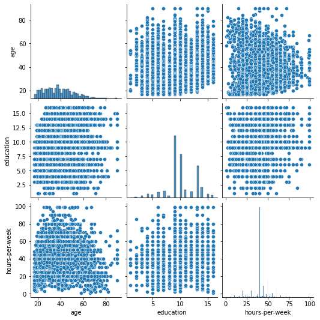

```python
adult_num= adult.select_dtypes(include=np.number)
sns.pairplot(adult_num)
```

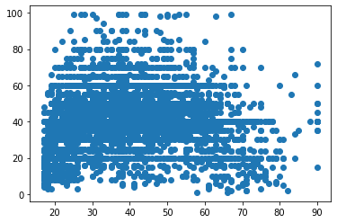

```python
plt.scatter(adult["age"],adult["hours-per-week"])
```

### Descriptive Analysis for Categorical Variables

*Solutions for PS1 Part2 and PS3*

```python
adult_cat= adult.select_dtypes(exclude="number")
print(adult_cat.isnull().values.sum())
adult_cat.head()
```

```
0
```

|  | workclass | marital-status | race | sex | income |
| --- | --- | --- | --- | --- | --- |
| 0 | Public | Single | White | Male | <=50K |
| 1 | Self-emp | Married | White | Male | <=50K |
| 2 | Private | Single | White | Male | <=50K |
| 3 | Private | Married | Black | Male | <=50K |
| 4 | Private | Married | Black | Female | <=50K |

#### I. Frequency Distribution of Categorical Variables

- The workclass variable contains 3 unique values, including private, public, and self-employeed, where the most frequent recorded value being private.
- The marital-status variable contains 2 unique values, including married and single. Although married is the more commonly occurred value, the difference between that and the frequency for single is not significant.
- The race variable contains 5 unique values, with the most commonly occurred value being white. There are more white adults observed in the dataset than observations from the rest of race combined. Notice that there are much fewer observations for Hispanic and American-Indian than the other race, which might lead to unaccountable conclusions for those two race groups.
- The sex variable contains 2 unique values, including male and female. Based on the frequency table, there are at least as twice observations from male adults as the females.
- Lastly, the income variable contains 2 unique values, including adults who make less or equal than 50k per year, and those who makes greater than 50k per year. Based on the output, adults who makes less or equal than 50k/year outnumbered those who make greater than 50k/per by a significant margin.

```python
print("Frequency distrubution of workclass variable: \n")
print(adult_cat["workclass"].value_counts())
print("\n")
print("Frequency distrubution of martial status variable: \n")
print(adult_cat["marital-status"].value_counts())
print("\n")
print("Frequency distrubution of race variable: \n")
print(adult_cat["race"].value_counts())
print("\n")
print("Frequency distrubution of sex variable: \n")
print(adult_cat["sex"].value_counts())
print("\n")
print("Frequency distrubution of income variable: \n")
print(adult_cat["income"].value_counts())
```

```
Frequency distrubution of workclass variable:

Private     6947
Public      1317
Self-emp    1148
Name: workclass, dtype: int64


Frequency distrubution of martial status variable:

Married    4737
Single     4675
Name: marital-status, dtype: int64


Frequency distrubution of race variable:

White          8062
Black           892
Asian           291
Amer-Indian      92
Hispanic         75
Name: race, dtype: int64


Frequency distrubution of sex variable:

Male      6383
Female    3029
Name: sex, dtype: int64


Frequency distrubution of income variable:

<=50K    7093
>50K     2319
Name: income, dtype: int64
```

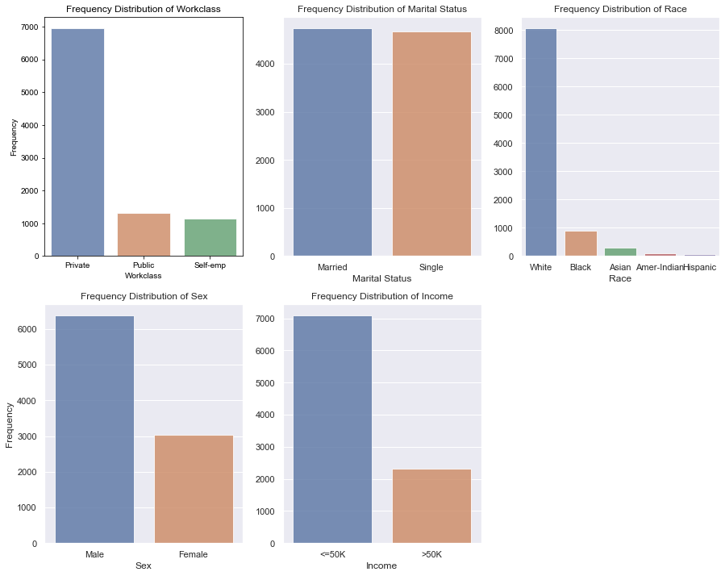

```python
#Barplot For Categorical Variables
%matplotlib inline

fig= plt.figure(figsize=(15,12))
plt.subplot(2,3,1)
workclass_count= adult_cat["workclass"].value_counts()
sns.set(style="darkgrid")
sns.barplot(x=workclass_count.index, y=workclass_count.values,alpha=.8)
plt.xlabel("Workclass")
plt.ylabel("Frequency")
plt.title("Frequency Distribution of Workclass")

plt.subplot(2,3,2)
ms_count= adult_cat["marital-status"].value_counts()
sns.set(style="darkgrid")
sns.barplot(x=ms_count.index, y=ms_count.values,alpha=.8)
plt.xlabel("Marital Status")
plt.title("Frequency Distribution of Marital Status")

plt.subplot(2,3,3)
race_count= adult_cat["race"].value_counts()
sns.set(style="darkgrid")
sns.barplot(x=race_count.index, y=race_count.values,alpha=.8)
plt.xlabel("Race")
plt.title("Frequency Distribution of Race")

plt.subplot(2,3,4)
sex_count= adult_cat["sex"].value_counts()
sns.set(style="darkgrid")
sns.barplot(x=sex_count.index, y=sex_count.values,alpha=.8)
plt.xlabel("Sex")
plt.ylabel("Frequency")
plt.title("Frequency Distribution of Sex")

plt.subplot(2,3,5)
income_count= adult_cat["income"].value_counts()
sns.set(style="darkgrid")
sns.barplot(x=income_count.index, y=income_count.values,alpha=.8)
plt.xlabel("Income")
plt.title("Frequency Distribution of Income")
```

### PS4. Cross Tabulations of Workclass & Race & Income

#### I. Workclass vs. Race

```python
#Table of workclass vs. race
wr= pd.crosstab(index=adult["workclass"], columns=adult["race"],
               margins=True)
wr
```

| race workclass | Amer-Indian | Asian | Black | Hispanic | White | All |
| --- | --- | --- | --- | --- | --- | --- |
| Private | 65 | 204 | 664 | 64 | 5950 | 6947 |
| Public | 20 | 48 | 192 | 5 | 1052 | 1317 |
| Self-emp | 7 | 39 | 36 | 6 | 1060 | 1148 |
| All | 92 | 291 | 892 | 75 | 8062 | 9412 |

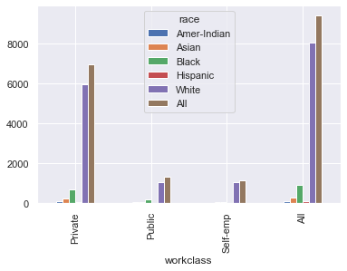

```python
plt.show(wr.plot(kind="bar"))
```

#### II. Workclass vs. Income

The contingency table below describes observation frequencies by their workclass and identified income bracket. Upon calculation, only 24.64% of adults in the dataset make more than 50k/year. Interestingly, the conditional probability of an adult who works in the public sector makes more than 50k/year is approximately 30%, while there is an approximately 37% probability for an adult who is self-empolyeed. Thus, the assumption is that self-employed freelancers earn more than those who are traditionally employed.

```python
#Table of workclass vs. income
wi= pd.crosstab(index=adult["workclass"], columns=adult["income"],
               margins=True)
wi
```

| income workclass | <=50K | >50K | All |
| --- | --- | --- | --- |
| Private | 5443 | 1504 | 6947 |
| Public | 925 | 392 | 1317 |
| Self-emp | 725 | 423 | 1148 |
| All | 7093 | 2319 | 9412 |

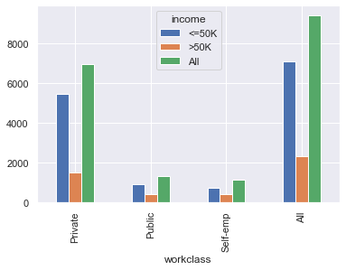

```python
plt.show(wi.plot(kind="bar"))
```

```python
# Total proportion of counts
wi/wi.loc["All","All"]
```

| income workclass | <=50K | >50K | All |
| --- | --- | --- | --- |
| Private | 0.578304 | 0.159796 | 0.738100 |
| Public | 0.098279 | 0.041649 | 0.139928 |
| Self-emp | 0.077029 | 0.044943 | 0.121972 |
| All | 0.753612 | 0.246388 | 1.000000 |

#### III. Race vs. Income

The contingency table below describes observation frequencies by their race and identified income bracket. Based on the output, white and asian adults in the dataset are more likely to make more than 50k/year, each with 26% and 23% probability respectively. On the other hand, Hispanic and American-Indian adults are more likely to earn less.

```python
#Table of race vs. income
ri= pd.crosstab(index=adult["race"], columns=adult["income"],
               margins=True)
ri
```

| income race | <=50K | >50K | All |
| --- | --- | --- | --- |
| Amer-Indian | 83 | 9 | 92 |
| Asian | 224 | 67 | 291 |
| Black | 773 | 119 | 892 |
| Hispanic | 69 | 6 | 75 |
| White | 5944 | 2118 | 8062 |
| All | 7093 | 2319 | 9412 |

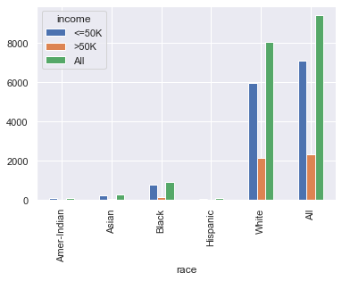

```python
plt.show(ri.plot(kind="bar"))
```

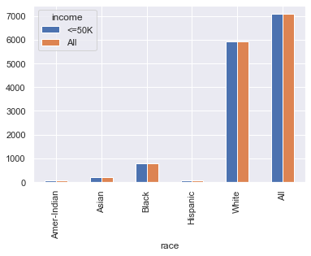

| income race | <=50K | All |
| --- | --- | --- |
| Amer-Indian | 0.011702 | 0.011702 |
| Asian | 0.031580 | 0.031580 |
| Black | 0.108981 | 0.108981 |
| Hispanic | 0.009728 | 0.009728 |
| White | 0.838009 | 0.838009 |
| All | 1.000000 | 1.000000 |

```python
lowincome= adult[adult.income == "<=50K"]
rilow= pd.crosstab(index=lowincome["race"], columns=lowincome["income"],margins=True)
plt.show(rilow.plot(kind="bar"))
rilow/rilow.loc["All"]
```

```python
# Total proportion of counts
rii= pd.crosstab(index=adult["race"], columns=adult["income"],
               margins=True,normalize="index")
rii
```

| income race | <=50K | >50K |
| --- | --- | --- |
| Amer-Indian | 0.902174 | 0.097826 |
| Asian | 0.769759 | 0.230241 |
| Black | 0.866592 | 0.133408 |
| Hispanic | 0.920000 | 0.080000 |
| White | 0.737286 | 0.262714 |
| All | 0.753612 | 0.246388 |

### PS5. Characteristics of Low vs. High Income Group

#### I. Key Characteristics: Workclass and Race

| race income workclass | Amer-Indian <=50K | Amer-Indian >50K | Asian <=50K | Asian >50K | Black <=50K | Black >50K | Hispanic <=50K | Hispanic >50K | White <=50K | White >50K | All |
| --- | --- | --- | --- | --- | --- | --- | --- | --- | --- | --- | --- |
| Private | 61 | 4 | 162 | 42 | 598 | 66 | 62 | 2 | 4560 | 1390 | 6947 |
| Public | 17 | 3 | 33 | 15 | 154 | 38 | 4 | 1 | 717 | 335 | 1317 |
| Self-emp | 5 | 2 | 29 | 10 | 21 | 15 | 3 | 3 | 667 | 393 | 1148 |
| All | 83 | 9 | 224 | 67 | 773 | 119 | 69 | 6 | 5944 | 2118 | 9412 |

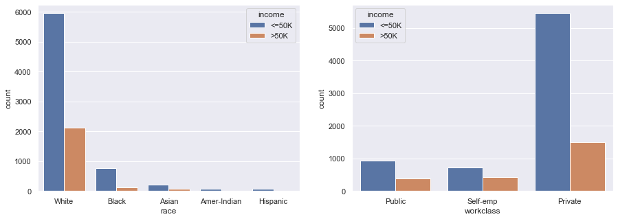

```python
wri= pd.crosstab(adult.workclass, [adult.race,adult.income],margins=True)

fig= plt.figure(figsize=(15,5))
plt.subplot(1,2,1)
sns.countplot(x="race",hue="income",data=adult)
plt.subplot(1,2,2)
sns.countplot(x="workclass",hue="income",data=adult)
wri
```

#### II. Other Characteristics

```python
lowincome.describe(include="all")
```

|  | age | workclass | education | marital-status | race | sex | hours-per-week | income |
| --- | --- | --- | --- | --- | --- | --- | --- | --- |
| count | 7093.000000 | 7093 | 7093.000000 | 7093 | 7093 | 7093 | 7093.000000 | 7093 |
| unique | NaN | 3 | NaN | 2 | 5 | 2 | NaN | 1 |
| top | NaN | Private | NaN | Single | White | Male | NaN | <=50K |
| freq | NaN | 5443 | NaN | 4363 | 5944 | 4424 | NaN | 7093 |
| mean | 36.635979 | NaN | 9.646976 | NaN | NaN | NaN | 39.567038 | NaN |
| std | 13.339117 | NaN | 2.397358 | NaN | NaN | NaN | 11.868506 | NaN |
| min | 17.000000 | NaN | 1.000000 | NaN | NaN | NaN | 1.000000 | NaN |
| 25% | 26.000000 | NaN | 9.000000 | NaN | NaN | NaN | 38.000000 | NaN |
| 50% | 35.000000 | NaN | 9.000000 | NaN | NaN | NaN | 40.000000 | NaN |
| 75% | 45.000000 | NaN | 10.000000 | NaN | NaN | NaN | 40.000000 | NaN |
| max | 90.000000 | NaN | 16.000000 | NaN | NaN | NaN | 99.000000 | NaN |

```python
highincome= adult[adult.income == ">50K"]
highincome.describe(include="all")
```

|  | age | workclass | education | marital-status | race | sex | hours-per-week | income |
| --- | --- | --- | --- | --- | --- | --- | --- | --- |
| count | 2319.000000 | 2319 | 2319.000000 | 2319 | 2319 | 2319 | 2319.000000 | 2319 |
| unique | NaN | 3 | NaN | 2 | 5 | 2 | NaN | 1 |
| top | NaN | Private | NaN | Married | White | Male | NaN | >50K |
| freq | NaN | 1504 | NaN | 2007 | 2118 | 1959 | NaN | 2319 |
| mean | 43.622251 | NaN | 11.588185 | NaN | NaN | NaN | 45.708495 | NaN |
| std | 10.047667 | NaN | 2.410764 | NaN | NaN | NaN | 10.678794 | NaN |
| min | 19.000000 | NaN | 2.000000 | NaN | NaN | NaN | 1.000000 | NaN |
| 25% | 36.000000 | NaN | 9.000000 | NaN | NaN | NaN | 40.000000 | NaN |
| 50% | 43.000000 | NaN | 12.000000 | NaN | NaN | NaN | 40.000000 | NaN |
| 75% | 50.000000 | NaN | 13.000000 | NaN | NaN | NaN | 50.000000 | NaN |
| max | 90.000000 | NaN | 16.000000 | NaN | NaN | NaN | 99.000000 | NaN |

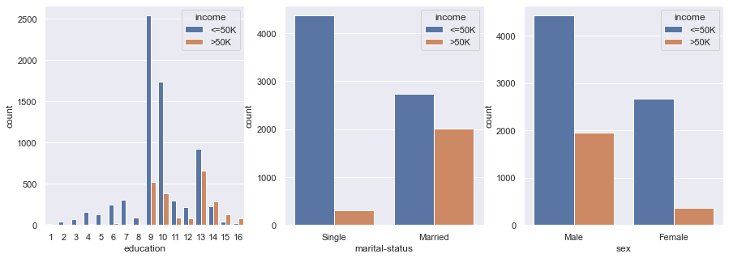

```python
fig= plt.figure(figsize=(15,5))
plt.subplot(1,3,1)
sns.countplot(x="education",hue="income",data=adult)

plt.subplot(1,3,2)
sns.countplot(x="marital-status",hue="income",data=adult)

plt.subplot(1,3,3)
sns.countplot(x="sex",hue="income",data=adult)
```

### PS 6. Dummy Variables

```python
adult_numeric = pd.get_dummies(adult, columns=["workclass","marital-status","race","sex","income"])
adult_numeric.to_csv("../documents/adult_numeric.csv", float_format="%1.2f")
adult_numeric.head(10)
```

|  | age | education | hours-per-week | workclass_Private | workclass_Public | workclass_Self-emp | marital-status_Married | marital-status_Single | race_Amer-Indian | race_Asian | race_Black | race_Hispanic | race_White | sex_Female | sex_Male | income_<=50K | income_>50K |
| --- | --- | --- | --- | --- | --- | --- | --- | --- | --- | --- | --- | --- | --- | --- | --- | --- | --- |
| 0 | 39 | 13 | 40 | 0 | 1 | 0 | 0 | 1 | 0 | 0 | 0 | 0 | 1 | 0 | 1 | 1 | 0 |
| 1 | 50 | 13 | 13 | 0 | 0 | 1 | 1 | 0 | 0 | 0 | 0 | 0 | 1 | 0 | 1 | 1 | 0 |
| 2 | 38 | 9 | 40 | 1 | 0 | 0 | 0 | 1 | 0 | 0 | 0 | 0 | 1 | 0 | 1 | 1 | 0 |
| 3 | 53 | 7 | 40 | 1 | 0 | 0 | 1 | 0 | 0 | 0 | 1 | 0 | 0 | 0 | 1 | 1 | 0 |
| 4 | 28 | 13 | 40 | 1 | 0 | 0 | 1 | 0 | 0 | 0 | 1 | 0 | 0 | 1 | 0 | 1 | 0 |
| 5 | 37 | 14 | 40 | 1 | 0 | 0 | 1 | 0 | 0 | 0 | 0 | 0 | 1 | 1 | 0 | 1 | 0 |
| 6 | 49 | 5 | 16 | 1 | 0 | 0 | 1 | 0 | 0 | 0 | 1 | 0 | 0 | 1 | 0 | 1 | 0 |
| 7 | 52 | 9 | 45 | 0 | 0 | 1 | 1 | 0 | 0 | 0 | 0 | 0 | 1 | 0 | 1 | 0 | 1 |
| 8 | 31 | 14 | 50 | 1 | 0 | 0 | 0 | 1 | 0 | 0 | 0 | 0 | 1 | 1 | 0 | 0 | 1 |
| 9 | 42 | 13 | 40 | 1 | 0 | 0 | 1 | 0 | 0 | 0 | 0 | 0 | 1 | 0 | 1 | 0 | 1 |

### PS7. Correlation Analysis

Since the Pearson correlation method assumes all variables are normally distributed, and the dataset is highly skewed due to outliers, with prescence of ordinal and nominal variables; Kendall's correlation is used to measure the degree of the relationship between linearly related variables. Kendall's correlation is a non-parametric method that does not require continuous or normal distributed data.

Although none of the pairs indicates a very strong correlation, the highest coefficients are plotted as below. Based on the heatmap, the highest pairwised correlation for two distinct attributes is .41, which is among income and marital status. This correlation relationship further proves the assumption that married adults are more likely to earn more than 50k/year than those who are single. Looking at the correlation of education with all other atributes, income>50k has the highest correlation coefficient with education, with a value of .28. Meantime, for adults who make less or equal than 50k/year, they are more likely to be associated with the attribute single.

```python
corr_matrix= adult_numeric.corr(method="kendall")
corr_matrix
```

|  | age | education | hours-per-week | workclass_Private | workclass_Public | workclass_Self-emp | marital-status_Married | marital-status_Single | race_Amer-Indian | race_Asian | race_Black | race_Hispanic | race_White | sex_Female | sex_Male | income_<=50K | income_>50K |
| --- | --- | --- | --- | --- | --- | --- | --- | --- | --- | --- | --- | --- | --- | --- | --- | --- | --- |
| age | 1.000000 | 0.044373 | 0.110746 | -0.174288 | 0.076994 | 0.152539 | 0.328725 | -0.328725 | -0.006862 | -0.007274 | -0.004442 | -0.026471 | 0.015944 | -0.066427 | 0.066427 | -0.222192 | 0.222192 |
| education | 0.044373 | 1.000000 | 0.121889 | -0.135757 | 0.137978 | 0.036124 | 0.044835 | -0.044835 | -0.033567 | 0.054008 | -0.070019 | -0.033919 | 0.049865 | -0.006190 | 0.006190 | -0.282786 | 0.282786 |
| hours-per-week | 0.110746 | 0.121889 | 1.000000 | -0.076785 | -0.026348 | 0.131092 | 0.178905 | -0.178905 | -0.000150 | -0.008328 | -0.087398 | 0.006180 | 0.075620 | -0.226635 | 0.226635 | -0.228371 | 0.228371 |
| workclass_Private | -0.174288 | -0.135757 | -0.076785 | 1.000000 | -0.677134 | -0.625700 | -0.121014 | 0.121014 | -0.007136 | -0.015060 | 0.004632 | 0.023490 | -0.000389 | 0.072569 | -0.072569 | 0.116453 | -0.116453 |
| workclass_Public | 0.076994 | 0.137978 | -0.026348 | -0.677134 | 1.000000 | -0.150335 | -0.002351 | 0.002351 | 0.022185 | 0.012883 | 0.070250 | -0.018927 | -0.066491 | 0.045338 | -0.045338 | -0.047981 | 0.047981 |
| workclass_Self-emp | 0.152539 | 0.036124 | 0.131092 | -0.625700 | -0.150335 | 1.000000 | 0.165075 | -0.165075 | -0.013931 | 0.006576 | -0.080694 | -0.011495 | 0.071008 | -0.145559 | 0.145559 | -0.105593 | 0.105593 |
| marital-status_Married | 0.328725 | 0.044835 | 0.178905 | -0.121014 | -0.002351 | 0.165075 | 1.000000 | -1.000000 | -0.013614 | 0.017852 | -0.104427 | 0.000605 | 0.082114 | -0.357736 | 0.357736 | -0.414173 | 0.414173 |
| marital-status_Single | -0.328725 | -0.044835 | -0.178905 | 0.121014 | 0.002351 | -0.165075 | -1.000000 | 1.000000 | 0.013614 | -0.017852 | 0.104427 | -0.000605 | -0.082114 | 0.357736 | -0.357736 | 0.414173 | -0.414173 |
| race_Amer-Indian | -0.006862 | -0.033567 | -0.000150 | -0.007136 | 0.022185 | -0.013931 | -0.013614 | 0.013614 | 1.000000 | -0.017746 | -0.032148 | -0.008905 | -0.242795 | 0.021711 | -0.021711 | 0.034254 | -0.034254 |
| race_Asian | -0.007274 | 0.054008 | -0.008328 | -0.015060 | 0.012883 | 0.006576 | 0.017852 | -0.017852 | -0.017746 | 1.000000 | -0.057795 | -0.016009 | -0.436496 | 0.001773 | -0.001773 | 0.006693 | -0.006693 |
| race_Black | -0.004442 | -0.070019 | -0.087398 | 0.004632 | 0.070250 | -0.080694 | -0.104427 | 0.104427 | -0.032148 | -0.057795 | 1.000000 | -0.028999 | -0.790710 | 0.106323 | -0.106323 | 0.084836 | -0.084836 |
| race_Hispanic | -0.026471 | -0.033919 | 0.006180 | 0.023490 | -0.018927 | -0.011495 | 0.000605 | -0.000605 | -0.008905 | -0.016009 | -0.028999 | 1.000000 | -0.219019 | 0.004766 | -0.004766 | 0.034607 | -0.034607 |
| race_White | 0.015944 | 0.049865 | 0.075620 | -0.000389 | -0.066491 | 0.071008 | 0.082114 | -0.082114 | -0.242795 | -0.436496 | -0.790710 | -0.219019 | 1.000000 | -0.097025 | 0.097025 | -0.092589 | 0.092589 |
| sex_Female | -0.066427 | -0.006190 | -0.226635 | 0.072569 | 0.045338 | -0.145559 | -0.357736 | 0.357736 | 0.021711 | 0.001773 | 0.106323 | 0.004766 | -0.097025 | 1.000000 | -1.000000 | 0.203886 | -0.203886 |
| sex_Male | 0.066427 | 0.006190 | 0.226635 | -0.072569 | -0.045338 | 0.145559 | 0.357736 | -0.357736 | -0.021711 | -0.001773 | -0.106323 | -0.004766 | 0.097025 | -1.000000 | 1.000000 | -0.203886 | 0.203886 |
| income_<=50K | -0.222192 | -0.282786 | -0.228371 | 0.116453 | -0.047981 | -0.105593 | -0.414173 | 0.414173 | 0.034254 | 0.006693 | 0.084836 | 0.034607 | -0.092589 | 0.203886 | -0.203886 | 1.000000 | -1.000000 |
| income_>50K | 0.222192 | 0.282786 | 0.228371 | -0.116453 | 0.047981 | 0.105593 | 0.414173 | -0.414173 | -0.034254 | -0.006693 | -0.084836 | -0.034607 | 0.092589 | -0.203886 | 0.203886 | -1.000000 | 1.000000 |

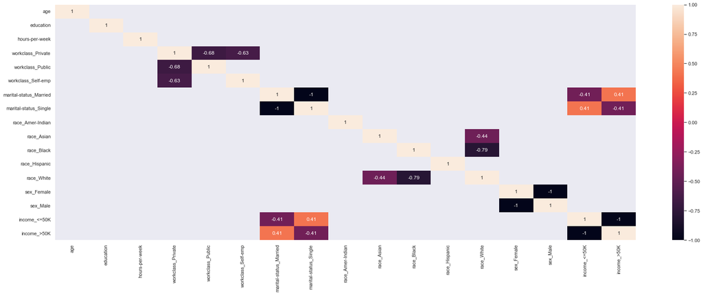

```python
filtered= corr_matrix[((corr_matrix >=.4)|(corr_matrix <= -.4) & (corr_matrix != 1))]
plt.figure(figsize=(30,10))
sns.heatmap(filtered, annot=True)
```

```python
corr_matrix["education"].sort_values(ascending=False)
```

```
education                 1.000000
income_>50K               0.282786
workclass_Public          0.137978
hours-per-week            0.121889
race_Asian                0.054008
race_White                0.049865
marital-status_Married    0.044835
age                       0.044373
workclass_Self-emp        0.036124
sex_Male                  0.006190
sex_Female               -0.006190
race_Amer-Indian         -0.033567
race_Hispanic            -0.033919
marital-status_Single    -0.044835
race_Black               -0.070019
workclass_Private        -0.135757
income_<=50K             -0.282786
Name: education, dtype: float64
```

```python
corr_matrix["income_<=50K"].sort_values(ascending=False)
```

```
income_<=50K              1.000000
marital-status_Single     0.414173
sex_Female                0.203886
workclass_Private         0.116453
race_Black                0.084836
race_Hispanic             0.034607
race_Amer-Indian          0.034254
race_Asian                0.006693
workclass_Public         -0.047981
race_White               -0.092589
workclass_Self-emp       -0.105593
sex_Male                 -0.203886
age                      -0.222192
hours-per-week           -0.228371
education                -0.282786
marital-status_Married   -0.414173
income_>50K              -1.000000
Name: income_<=50K, dtype: float64
```